# First Assignment

Sebastian Feist

07/31/2024

# Please complete all the tasks listed below. After completing the tasks download the .Rmd file and upload in the peer review item for grading.

# Additionally please write text between the code chunks explaining what each code chunk is about

1.a bulleted list with sub-bullets under at least one item (10 pt)

- Peugeot
  - 208
  - 308
- Volkswagen
  - Polo
  - Golf
- Skoda
  - Fabia
  - Octavia

Unordered list items need to start with *, -, or +.

2.a numbered list (10 pt)

1. Fidelio
2. Chili
3. Luzie

Ordered list items start with the numbers.

3.some words italicized (5 pt)

*Rome* *Venice* *Florence*

To write words in italics you have to use either asterisks * or underscores _.

4.some words in bold print (5 pt)

**Chengdu** **Chongqing** **Guangdong**

To make text bold you can use double asterisks ** or double underscores __.

5. two levels of headers (10 pt)

# First-level header

## Second-level header

The number of # symbols you use at the beginning of the line determines the level of the header.

6.the results of some R code without showing the code (10 pt)

```
## [1] 1 2 3 4 5 6
```

With the chunk option echo you can choose to show or not to show the code. So with echo=false it shows only the value which I assigned x.

7.a table of text at least 3 columns wide and 3 rows long

```r
# this creates a data frame with 3 columns and 3 rows
data <- data.frame(
  Column1 = c("1", "2", "3"),
  Column2 = c("One", "Two", "Three"),
  Column3 = c("Eins", "Zwei", "Drei")
)
# this uses the knitr package to generate the table
knitr::kable(data)
```

| Column1 | Column2 | Column3 |
| --- | --- | --- |
| 1 | One | Eins |
| 2 | Two | Zwei |
| 3 | Three | Drei |

8.a plot (show the code that generates the plot) (10 pt)

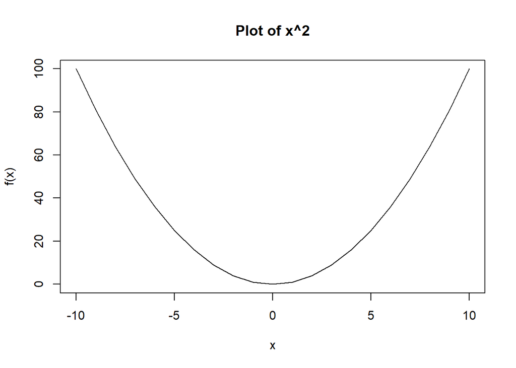

```r
# this defines the function
f <- function(x) {
  x^2
}

# now I generate a sequence of x values
x <- seq(-10, 10)

# this plots the function
plot(x, f(x), type = "l", xlab = "x", ylab = "f(x)", main = "Plot of x^2")
```

10.Execution of .Rmd file (10 pt)

11. Upload and execution of knitted pdf (10 pt)